# Assignment 3: Supervised learning competition

# Model comparison

Within each model type (K-Nearest Neighbour (KNN), Linear regression and Random Forest), the optimal model was selected based on cross-validation performance. For random forest, mtry = 16 has the best result (rf_model6). For KNN, the optimal model is kmax = 21, distance = 2 and kernel = gaussian (model_knn_top10_corr). Finally, for the linear regression, it is the model with the lowest Mean Squared Error (MSE), which is model regression_top10. We then compared the best models with each other, using the 10-fold cross-validation.

When it comes to R-squared, Random Forest obtains an R-squared of 0.2569956, KNN obtains an R-squared of 0.2384261, and Linear regression obtains an R-squared of 0.2322802. Since a value closer to 1 means a better mode, Random Forest performs better, followed by KNN and Linear Regression. But, looking at Figure 32, Linear Regression seems to have a higher R-squared value than KNN. It is due to the fact that the boxplot shows the median, while the summary numbers show the mean of all 10 folds. It means that KNN R² means is higher, but its median is lower than Linear Regression. However, it is not really relevant for our analysis, as we are looking at the MSE score to select the best model.

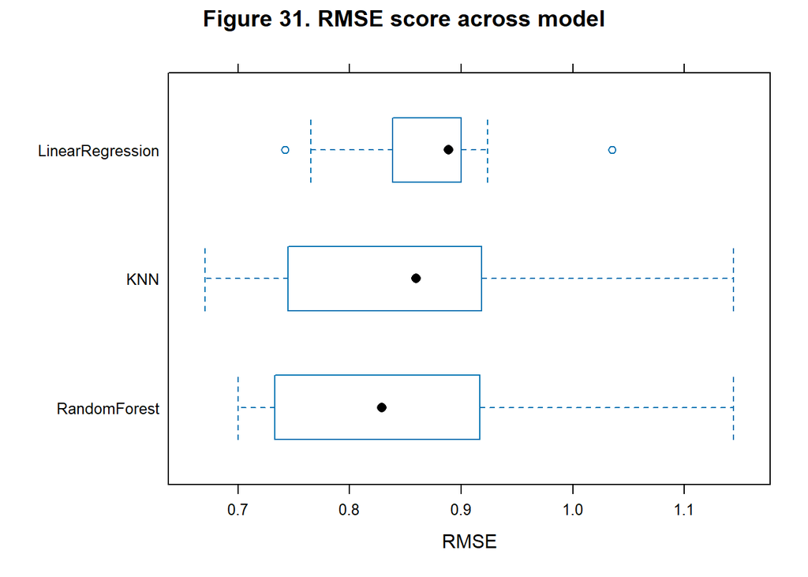

```r
# Create results comparison
results <- resamples(list(
  LinearRegression = regression_top10,
  KNN = model_knn_top10_corr,
  RandomForest = rf_model6
))

# Create RMSE and R-squared plots
bwplot(results, metric = "RMSE", main = "Figure 31. RMSE score across model")
```

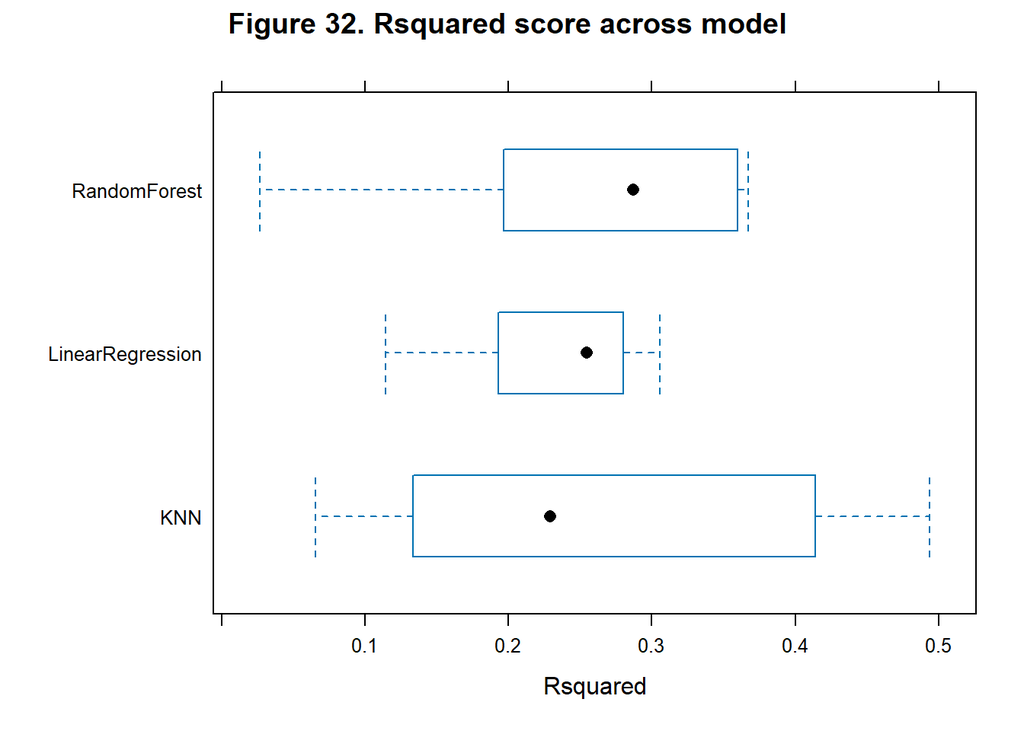

```r
bwplot(results, metric = "Rsquared", main = "Figure 32. Rsquared score across model ")
```

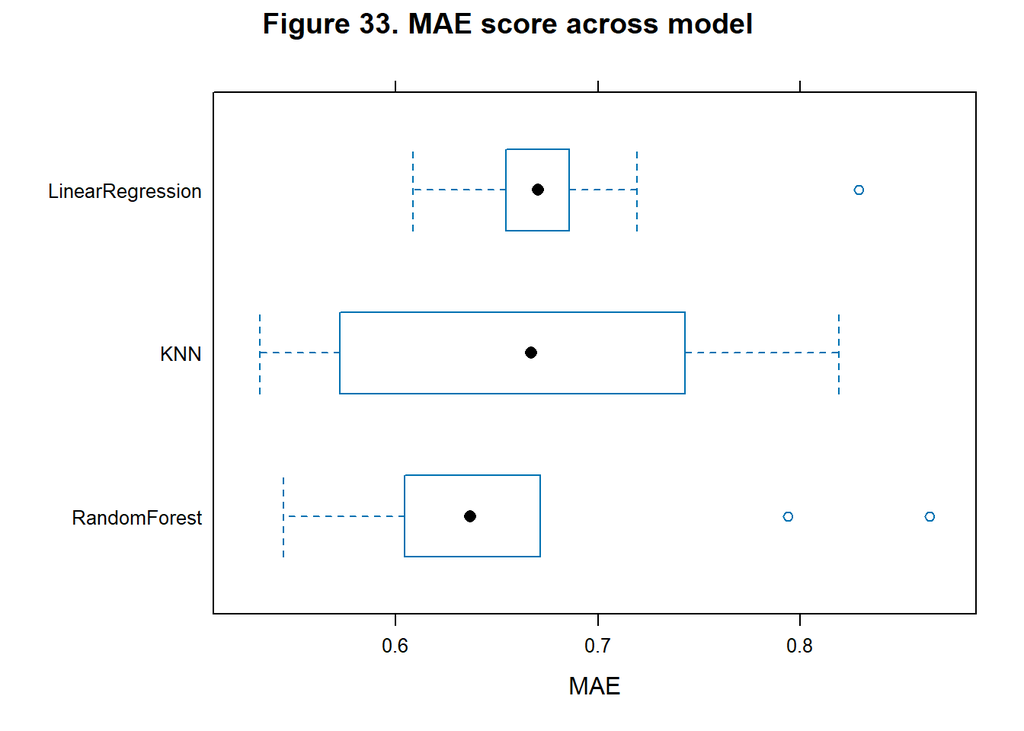

```r
bwplot(results, metric = "MAE", main = "Figure 33. MAE score across model ")
```

```r
# Extract RMSE values for MSE calculation
rmse_vals <- results$values[, grep("RMSE", names(results$values))]

# Compute MSE from RMSE
mse_vals <- rmse_vals^2
mse_df <- melt(mse_vals, variable.name = "Model", value.name = "MSE")

# Clean up model names
names(mse_df) <- c("Model", "MSE")
mse_df$Model <- gsub("~RMSE", "", mse_df$Model)
```

# Chosen model

When comparing the MSE score between models, we see that Random Forest is the most performant one, as its MSE is 0.7274642 (a lower number means a better performance). KNN’s MSE is 0.7587485 and Linear Regression’s MSE is 0.7595943, therefore, we consider these two models are having similar performance.

```r
rmse_best <- c(
  LinearRegression = 0.8715471,
  KNN = 0.8710617,
  RandomForest = 0.8529151
)

mse_best <- rmse_best^2



data.frame(
  Model = names(mse_best),
  MSE = as.numeric(mse_best),
  row.names = NULL
)
```

| Model | MSE |
| --- | --- |
| LinearRegression | 0.7595943 |
| KNN | 0.7587485 |
| RandomForest | 0.7274642 |

# Prediction creation

```r
# Make predictions using the best model (Random Forest)
predictions <- predict(rf_model6, newdata = test_data)

# Store predictions
write_rds(predictions, "predictions.rds")
```

# Team member contributions

- Menno: Wrote the first half of the report (up to the model comparisons)
- Ilse: Linear regression model, data pre-processing, visualisation.
- Zoé Ricardie: heatmap (data visualisation), model comparison, chosen model and prediction creation.
- Majdouline: KNN model, visualisation.
- Zexuan: Random Forest model, data pre-processing, combined works together into reports.

# References

Erola et al (2016): https://doi.org/10.1016/j.rssm.2016.01.003

Komorowski et al. (2016) https://doi.org/10.1007/978-3-319-43742-2_15

Rakesh et al (2024): https://doi.org/10.1111/jcpp.14082

Munir et al (2023): https://doi.org/10.54183/jssr.v3i2.308

Yuen et al (2023) https://doi.org/10.3389/fpsyg.2023.1253842

Erola, J., Jalonen, S., & Lehti, H. (2016). Parental education, class and income over the early life course and children’s achievement. Research in Social Stratification and Mobility, 44, 33–43. https://doi.org/10.1016/j.rssm.2016.01.003

Komorowski, M., Marshall, D. C., Salciccioli, J. D., & Crutain, Y. (2016). Exploratory data analysis. In M. M. Ghassemi, M. Naumann, S. J. Shah, & G. Szolovits (Eds.), Secondary Analysis of Electronic Health Records (pp. 185–203). Springer. https://doi.org/10.1007/978-3-319-43742-2_15

Rakesh, D., Lee, P. A., Gaikwad, A., & McLaughlin, K. A. (2025). Associations of socioeconomic status with cognitive function, language ability, and academic achievement in youth: A systematic review of mechanisms and protective factors. Journal of Child Psychology and Psychiatry, 66(4), 417–439. https://doi.org/10.1111/jcpp.14082

Munir, J., Faiza, M., Jamal, B., Daud, S., & Iqbal, K. (2023). The impact of socio-economic status on academic achievement. Journal of Social Sciences Review, 3(2), 695–705. https://doi.org/10.54183/jssr.v3i2.308

Yuen, C. Y. M., Cheung, A. C. K., & Leung, K. H. (2023). Effects of salient factors on the pursuit of higher education among multicultural youth in Hong Kong. Frontiers in Psychology, 14. https://doi.org/10.3389/fpsyg.2023.1253842